# Simulating CO T->P leakage from bandpass mismatch

Planck realeased several CO maps obtained with different component separation methodologies.

Since we want to simulate for LB, we adopted maps at lower resolution obtained with COMMANDER (whose SNR is fairly larger compared to other kind of CO maps released).

Below the three CO intensity maps

```python
import pylab as pl
from  numpy.random import normal
import numpy as np
import healpy as hp
from scipy.signal import periodogram
from pylab import cm
cmap = cm.get_cmap('RdYlBu')
cmap.set_under('w')
```

```python
from IPython.display import HTML

HTML('''<script>
code_show=true;
function code_toggle() {
 if (code_show){
 $('div.input').hide();
 } else {
 $('div.input').show();
 }
 code_show = !code_show
}
$( document ).ready(code_toggle);
</script>
<form action="javascript:code_toggle()"><input type="submit" value="Click here to toggle on/off the raw code."></form>''')
```

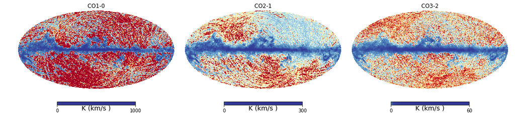

```python
dirmaps='/Users/peppe/work/FG_modeling/CO/data/Planck_maps/'

co10 =hp.mrdfits(hdu=1,
                 filename=dirmaps+'COM_CompMap_CO-commander_0256_R2.00.fits')[0]
co21 =hp.mrdfits(hdu=2,
                 filename=dirmaps+ 'COM_CompMap_CO-commander_0256_R2.00.fits')[0]

co32 =hp.mrdfits(hdu=3,
                 filename=dirmaps+ 'COM_CompMap_CO-commander_0256_R2.00.fits')[0]

fig=pl.figure(figsize=(15,8))

hp.mollview(co10, cmap=cmap, nest=True, sub=131, fig=fig,norm='hist', title= ' CO1-0 ', max=1000, unit= 'K (km/s )')
hp.mollview(co21, cmap=cmap, nest=True, sub=132, fig=fig,norm='hist', title= ' CO2-1 ', max=300, unit= 'K (km/s )')
hp.mollview(co32, cmap=cmap, nest=True, sub=133, fig=fig,norm='hist', title= ' CO3-2 ', max=60, unit= 'K (km/s )')
```

**Caption** CO maps from COMMANDER for the first 3 CO rotational lines. Maps are realeased in the units of $K (km s^{-1}) $, we converted them into $K_{CMB}$ by multplying the measured spectral bandpass of the detectors $F_{CO}$ (as explained in Planck Collaboration IX (2014) and Planck Collaboration XIII (2014) ) with the average CO conversion coefficients :

- CO 1-0 : $1.42 \times 10 ^{-5} K_{CMB}/ K (km s^{-1})$
- CO 2-1 : $4.50\times 10 ^{-5} K_{CMB}/ K (km s^{-1})$
- CO 3-2 : $17.37 \times 10 ^{-5} K_{CMB}/ K (km s^{-1})$

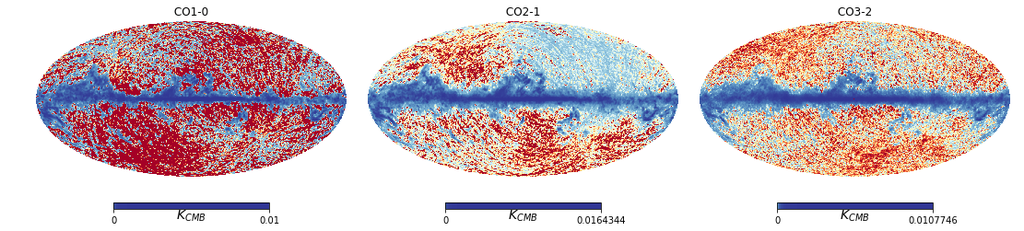

```python
fCO= {'1-0': 1.42e-5, '2-1':4.5e-5, '3-2':17.37e-5}

co10K = ( fCO ['1-0'] ) *co10
co21K = (fCO ['2-1'] ) *co21
co32K = ( fCO ['3-2'] ) *co32

fig=pl.figure(figsize=(15,8))
hp.mollview(co10K, cmap=cmap, nest=True, sub=131,max=.01, fig=fig,norm='hist', title= ' CO1-0 '  , unit= r'$K_{CMB}$ ')
hp.mollview(co21K, cmap=cmap, nest=True, sub=132, fig=fig,norm='hist', title= ' CO2-1 ' , unit=  r'$K_{CMB}$ ')
hp.mollview(co32K, cmap=cmap, nest=True, sub=133, fig=fig,norm='hist', title= ' CO3-2 ' , unit=  r'$K_{CMB}$ ')
hp.write_map(dirmaps+'COM_CompMap_CO10-commander_0256_R2.00.fits',
             [ co10K, pl.zeros_like(co10),  pl.zeros_like(co10)] ,
             nest=True , overwrite=True)
hp.write_map(dirmaps+'COM_CompMap_CO21-commander_0256_R2.00.fits',
             [ co21K, pl.zeros_like(co10),  pl.zeros_like(co10)] ,
             nest=True , overwrite=True)
hp.write_map(dirmaps+'COM_CompMap_CO32-commander_0256_R2.00.fits',
             [ co32K, pl.zeros_like(co10),  pl.zeros_like(co10)] ,
             nest=True , overwrite=True)
```

## Rotate into Ecliptic coord

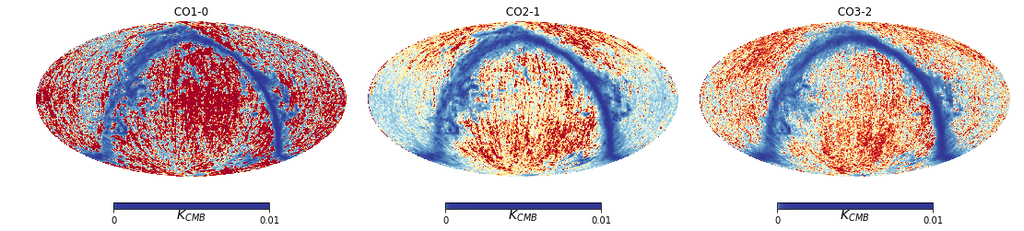

```python
co10Ke = hp.read_map(dirmaps+'COM_CompMap_CO10-commander_0256_R2.00_E.fits', verbose=False , nest=True)
co21Ke = hp.read_map(dirmaps+'COM_CompMap_CO21-commander_0256_R2.00_E.fits', verbose=False , nest=True)
co32Ke = hp.read_map(dirmaps+'COM_CompMap_CO32-commander_0256_R2.00_E.fits', verbose=False , nest=True)

fig=pl.figure(figsize=(15,8))
hp.mollview(co10Ke, cmap=cmap, nest=True, sub=131,max=.01, fig=fig,norm='hist', title= ' CO1-0 '  , unit= r'$K_{CMB}$ ')
hp.mollview(co21Ke, cmap=cmap, nest=True, sub=132,max=.01 , fig=fig,norm='hist', title= ' CO2-1 ' , unit=  r'$K_{CMB}$ ')
hp.mollview(co32Ke, cmap=cmap, nest=True, sub=133,max=.01, fig=fig,norm='hist', title= ' CO3-2 ' , unit=  r'$K_{CMB}$ ')
```

## Sims w/ CO 1-0

We injected bandpass mismatches by simulating 1 yr of LB signal -only observations performed by 2 detector pair. We model the observed TOD signal as of the two detectors A, B as :

$$ d^A_t = f s_{CO} $$ $$ d^b_t = \epsilon f s_{CO} $$

where $f$ and $\epsilon $ parametrize the bandpass mismatch of the detector pair and $s_{CO} $ is the scanned CO intensity only map (see above, no polarization). So far we consider $f$ and $\epsilon $ constant during the whole observation period:

$f= 0.5 $ and $\epsilon = 0.3 $

We therefore want to assess the level of T-> P leakage from CO lines to QU maps.

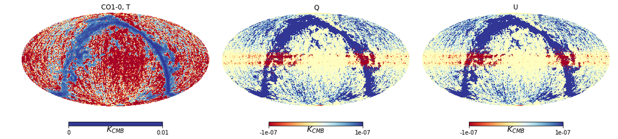

```python
mco10b= hp.read_map('/Users/peppe/work/satellite_sims/CO_bandpass/madam_bmap_003.fits', field=range(3), verbose=False)

fig=pl.figure(figsize=(15,8))
mco10b[0]/=0.5
hp.mollview(mco10b[0] , cmap=cmap , sub=131, fig=fig,norm='hist',max=.01,min=0., title= ' CO1-0, T '  , unit= r'$K_{CMB}$ ')
hp.mollview(mco10b[1] , cmap=cmap , sub=132, fig=fig , title= '  Q ' , unit=  r'$K_{CMB}$ ', min=-1e-7, max=1e-7)
hp.mollview(mco10b[2], cmap=cmap , sub=133, fig=fig ,  title= ' U ' , unit=  r'$K_{CMB}$ ', min=-1e-7, max=1e-7)
```

```python
mask=hp.read_map('/Users/peppe/work/satellite_sims/CO_bandpass/Galactic_binaryMask_16perc_256_nest.fits',
                 verbose=False)

cl = pl.loadtxt('/Users/peppe/work/satellite_sims/Class_planck2015_r0_cl_lensed.dat')
lmax=3*hp.get_nside(mco10)
l=pl.arange(2, lmax+1)
Nl =lambda w: (pl.pi /180. /60. * w)**2
wp=7.6 # uK arcmin
Nl0= Nl(wp)
masked_co= [i*mask  for i in mco10b]
clleakage =hp.anafast(masked_co,lmax=lmax,  )
```